# High Dimensional Data

> This RMD will take a long time to knit - more than 1 hour!

## Introduction

What happens when a data set has too many variables ? Here are few possible situations which you might come across:

- You find that most of the variables are correlated.
- You lose patience and decide to run a model on whole data. This returns poor accuracy and you feel terrible.
- You become indecisive about what to do
- You start thinking of some strategic method to find few important variables

I can’t remember the last time I worked on a data set with less than 500 features. This isn’t a big deal with today’s computing power, but it can become unwieldy when you need to use certain forest-based models, heavy cross-validation, grid tuning, or any ensemble work. Note: the term variables, features, predictors are used throughout and mean the same thing.

Here are some ways of dealing with high-dimensionality data (i.e. having too many variables) are:

1. Get more computing muscle,
2. Prune your data set using feature selection (measure variables effectiveness and keeps only the best - built-in feature selection - see [fscaret](http://amunategui.github.io/fscaret-Walkthrough/)),
3. Work on a sample subset or break up the data into chunks,
4. Use feature reduction (also refereed as feature extraction) to create new variables made of bits and pieces of the original variables. (Thats what we are going to do.)

According to Wikipedia: *Principal component analysis (PCA) is a statistical procedure that uses an orthogonal transformation to convert a set of observations of possibly correlated variables into a set of values of linearly uncorrelated variables called principal components.*

Principal component analysis (PCA) looks for the set of related variables in your data that explain most of the variance and creates a new feature out of it. This becomes your first component. It will then keep doing so on the next set of variables unrelated to the first and that becomes your next component and so on. This is done in an unsupervised manner so it doesn’t care what your response variable/outcome is (but you should exclude it from your data before feeding it into PCA).

The matrix should be numeric and have standardized data. The principal components are supplied with normalized version of original predictors. This is because, the original predictors may have different scales. For example: Imagine a data set with variables’ measuring units as gallons, kilometers, light years etc. It is definite that the scale of variances in these variables will be large. Performing PCA on un-normalized variables will lead to insanely large loadings for variables with high variance. In turn, this will lead to dependence of a principal component on the variable with high variance. This is undesirable.

PCA can be applied only on numerical data. Therefore, if the data has categorical variables they must be converted to numerical. Also, make sure you have done the basic data cleaning prior to implementing this technique.

Package {stats} There are plenty of PCA libraries in R, in this course, we’ll focus on two common ones available in the base {stats} package (i.e. you don’t have to download any package, its already there):

1. **princomp** performs a principal components analysis on the given numeric data matrix and returns the results as an object of class “princomp”.
2. **prcomp** Performs a principal components analysis on the given data matrix and returns the results as an object of class “prcomp”. They both perform PCA but get there in slightly different ways - princomp uses the *eigen function* while prcomp uses *singular value decomposition* of the data. I won’t pretend to understand the nuances between both approaches, and as I want to stay away from formulas and keep this very practical, I will only say that **it is important to know the existence of both functions. If one doesn’t work on a particular data set, try the other**. . . .

Below several examples are provided to show how to use PCA.

### Example 1 - prcomp

Since skewness and the magnitude of the variables influence the resulting PCs, it is good practice to apply skewness transformation, center and scale the variables prior to the application of PCA. In the example below, we applied a log transformation to the variables but we could have been more general and applied a Box and Cox transformation. See Example 2 how to perform all those transformations and then apply PCA with only one call to the preProcess function of the caret package.

```r
data <- log(USArrests)
head(data)
```

```
##              Murder  Assault UrbanPop     Rape
## Alabama    2.580217 5.463832 4.060443 3.054001
## Alaska     2.302585 5.572154 3.871201 3.795489
## Arizona    2.091864 5.683580 4.382027 3.433987
## Arkansas   2.174752 5.247024 3.912023 2.970414
## California 2.197225 5.620401 4.510860 3.703768
## Colorado   2.066863 5.318120 4.356709 3.655840
```

```r
str(data)
```

```
## 'data.frame':    50 obs. of  4 variables:
##  $ Murder  : num  2.58 2.3 2.09 2.17 2.2 ...
##  $ Assault : num  5.46 5.57 5.68 5.25 5.62 ...
##  $ UrbanPop: num  4.06 3.87 4.38 3.91 4.51 ...
##  $ Rape    : num  3.05 3.8 3.43 2.97 3.7 ...
```

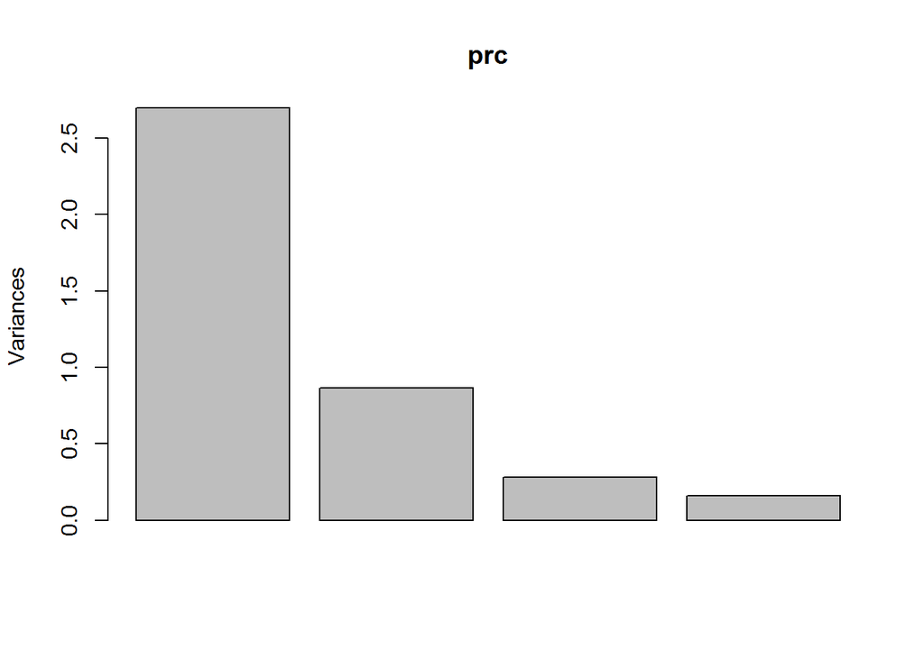

```r
prc <- prcomp(data, scale = TRUE, center = TRUE)
screeplot(prc)
```

```r
#screeplot.default plots the variances against the number of the principal component. This is also the plot method for classes "princomp" and "prcomp".
summary(prc)
```

```
## Importance of components:
##                           PC1    PC2     PC3     PC4
## Standard deviation     1.6423 0.9290 0.53007 0.39879
## Proportion of Variance 0.6743 0.2157 0.07024 0.03976
## Cumulative Proportion  0.6743 0.8900 0.96024 1.00000
```

The most important piece of information from the summary information is the Proportion of Variance - the middle record above. PC1 holds 67% of all the variance. PC1 + PC2 = 89% of all the variance. (This is of course also shown in the plot above too.)

If you square the standard deviation will return the eigen value. The rule suggests any value greater than 1 is important. You can see below that PC1 and PC2 are greater or very close to 1.

```r
prc$sdev^2
```

```
## [1] 2.6970040 0.8629851 0.2809769 0.1590341
```

Biplot is the projection of your data on the first two principal components (where the variances are the highest).

Interpreting Points: The relative location of the points can be interpreted. Points that are close together correspond to observations that have similar scores on the components displayed in the plot. To the extent that these components fit the data well, the points also correspond to observations that have similar values on the variables.

Interpreting Vectors: Both the direction and length of the vectors can be interpreted. Vectors point away from the origin in some direction. A vector points in the direction which is most like the variable represented by the vector. This is the direction which has the highest squared multiple correlation with the principal components. The length of the vector is proportional to the squared multiple correlation between the fitted values for the variable and the variable itself.

The fitted values for a variable are the result of projecting the points in the space orthogonally onto the variable’s vector (to do this, you must imagine extending the vector in both directions). The observations whose points project furthest in the direction in which the vector points are the observations that have the most of whatever the variable measures. Those points that project at the other end have the least. Those projecting in the middle have an average amount. Thus, vectors that point in the same direction correspond to variables that have similar response profiles and can be interpreted as having similar meaning in the context set by the data.

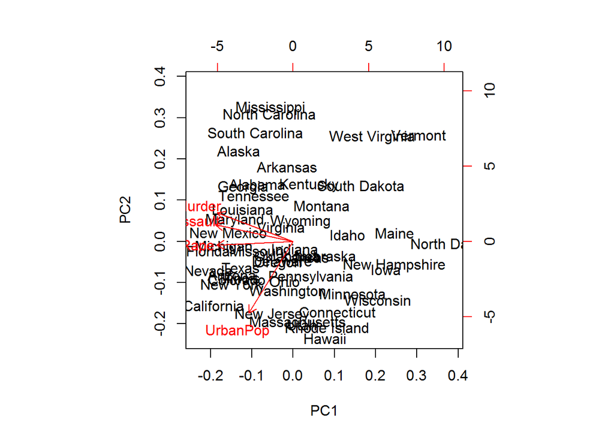

```r
biplot(prc)
```

Interpretation of biplot : For each of 50 stats in the USA, the data set contains the number of arrests per 100,000 residents for each three crimes: Assault, Murder and Rape. Also urbanpop represents percent of the population in each state living in urban areas. The plot shows the first two principal component scores and the loading vectors in a single biplot display. The loadings are given below:

```r
prc$rotation
```

```
##                 PC1         PC2        PC3        PC4
## Murder   -0.5418638  0.36131309 -0.1783223  0.7375891
## Assault  -0.5539712  0.21230365 -0.4990861 -0.6316298
## UrbanPop -0.3174305 -0.90674836 -0.2300113  0.1553708
## Rape     -0.5465688 -0.04676995  0.8162163 -0.1812902
```

From the plot as wells from the above loadings what we can understand is, first loading vector places approximately equal weight on Assault, Murder and Rape, with much less weight on urbanpop. Hence this component roughly corresponds to a measure of overall rates of serious crimes.

The second loading vector places most of it weight on Urbanpop and much less weight on the other 3 features. Hence, this component roughly corresponds to the level of urbanization of the state. Overall, we see that the crime-related variables are located close to each other, and that the urbanpop variable is far from other three. This indicates hat the crime related variables are correlated with each other-States with high murder rates tend to had high assault and rape rates. Urbanpop variable is less correlated with the other three.

Notice that the crimes are closely related compared with Urban Pop component. As an example, if we sort the data by Urban Pop, we see that California has the highest population and that state is right next to the Urban Pop point. Conversely, Vermont is the least populated state and that point is nearly opposite California.

```r
head(USArrests[order(USArrests$UrbanPop,decreasing=TRUE),], 3)
```

```
##              Murder Assault UrbanPop Rape
## California      9.0     276       91 40.6
## New Jersey      7.4     159       89 18.8
## Rhode Island    3.4     174       87  8.3
```

```r
head(USArrests[order(USArrests$UrbanPop,decreasing=FALSE),], 3)
```

```
##               Murder Assault UrbanPop Rape
## Vermont          2.2      48       32 11.2
## West Virginia    5.7      81       39  9.3
## Mississippi     16.1     259       44 17.1
```

There is package called ‘ggbiplot’ available in github which yields much better illustration on PCA.

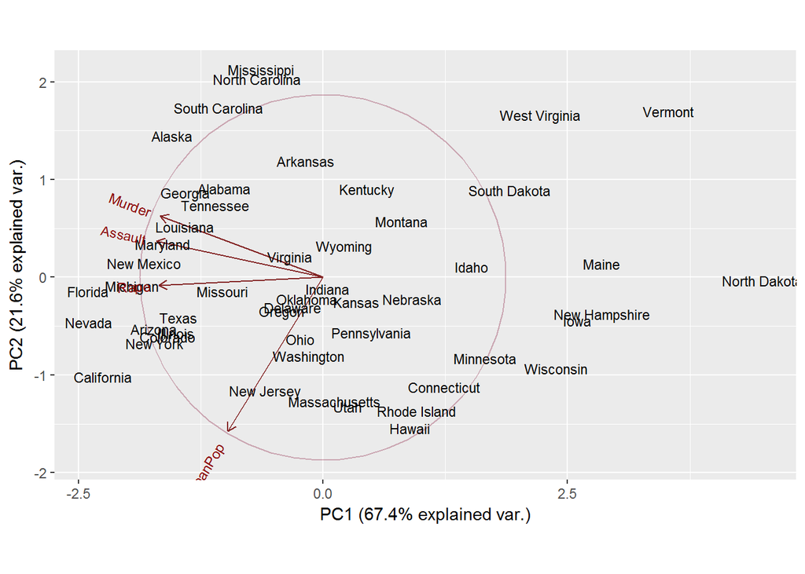

```r
g <- ggbiplot(prc, obs.scale = 1, var.scale = 1, labels=row.names(USArrests),
              ellipse = TRUE, circle = TRUE)
g <- g + scale_color_discrete(name = '')
g <- g + theme(legend.direction = 'horizontal', legend.position = 'top')
print(g)
```

I am not sold on the actual utility of the biplot. It is nice to look at but how is it truly actionable?

### Example 2 - Repeat Example 1 with caret

In Example 1 above, we applied skewness transformation, center and scale the variables prior to the application of PCA using a log transformation to the variables but we could have been more general and applied a Box and Cox transformation.

#### Box abd Cox Transformation

When an attribute has a Gaussian-like distribution but is shifted, this is called a skew. The distribution of an attribute can be shifted to reduce the skew and make it more Gaussian. The BoxCox transform can perform this operation (assumes all values are positive).

Normally distributed data is needed to use a number of statistical analysis tools, such as individuals control charts, t-tests and analysis of variance (ANOVA). When data is not normally distributed, the cause for non-normality should be determined and appropriate remedial actions should be taken. Transforming data means performing the same mathematical operation on each piece of original data.

The statisticians George Box and David Cox developed a procedure to identify an appropriate exponent (Lambda = l) to use to transform data into a “normal shape.” The Lambda value indicates the power to which all data should be raised. In order to do this, the Box-Cox power transformation searches from Lambda = -5 to Lamba = +5 until the best value is found.

The Box-Cox power transformation is not a guarantee for normality. This is because it actually does not really check for normality; the method checks for the smallest standard deviation. The assumption is that among all transformations with Lambda values between -5 and +5, transformed data has the highest likelihood – but not a guarantee – to be normally distributed when standard deviation is the smallest. Therefore, it is absolutely necessary to always check the transformed data for normality using a probability plot.

Additionally, the Box-Cox Power transformation only works if all the data is positive and greater than 0. This, however, can usually be achieved easily by adding a constant to all data such that it all becomes positive before it is transformed.

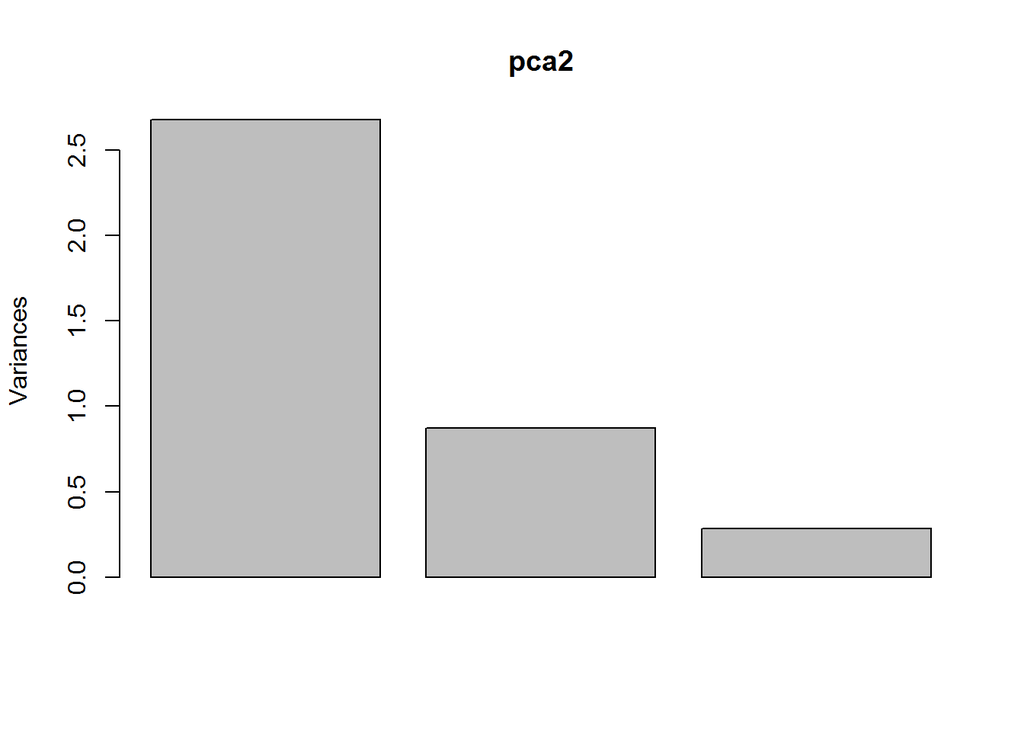

```r
pca2_transform <- preProcess(data, method = c("BoxCox", "center", "scale", "pca"))
pca2_preprocess <- predict(pca2_transform, newdata = data)
pca2 <- prcomp(pca2_preprocess, center = TRUE)
screeplot(pca2)
```

```r
summary(pca2)
```

```
## Importance of components:
##                           PC1    PC2     PC3
## Standard deviation     1.6368 0.9331 0.53357
## Proportion of Variance 0.6987 0.2271 0.07424
## Cumulative Proportion  0.6987 0.9258 1.00000
```

Learn more about caret and preProcess here: http://machinelearningmastery.com/pre-process-your-dataset-in-r/

### Example 3 - princomp

In this case, princomp and prcomp are very similar.

```r
prc2 <- princomp(data, cor = TRUE, scale=TRUE, center=TRUE)
summary(prc2)
```

```
## Importance of components:
##                          Comp.1    Comp.2     Comp.3     Comp.4
## Standard deviation     1.642256 0.9289699 0.53007252 0.39879074
## Proportion of Variance 0.674251 0.2157463 0.07024422 0.03975851
## Cumulative Proportion  0.674251 0.8899973 0.96024149 1.00000000
```

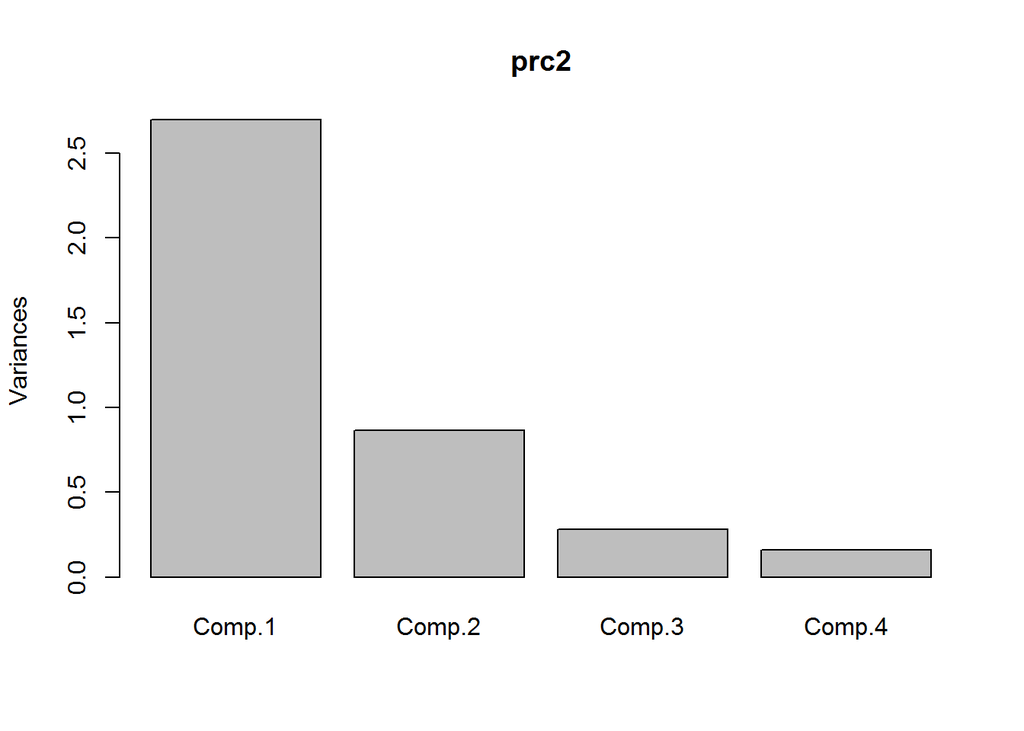

```r
screeplot(prc2)
```

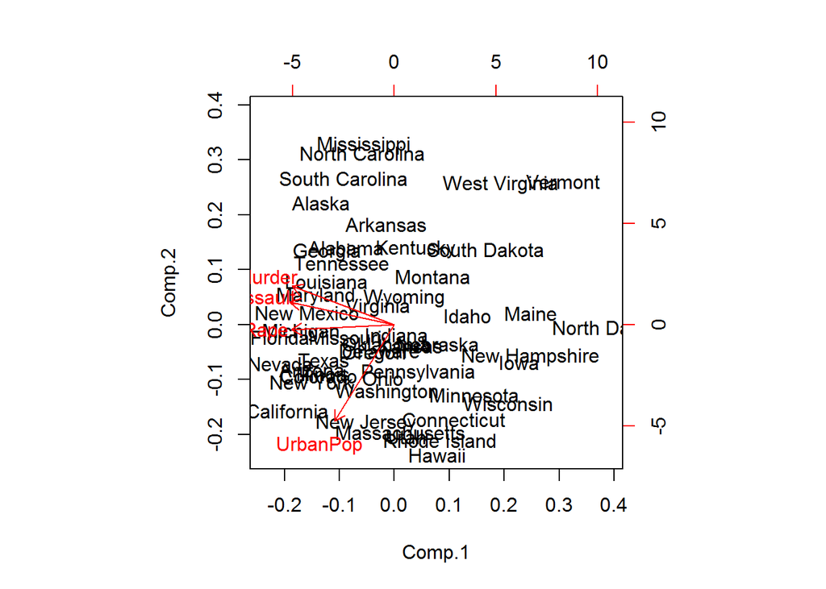

```r
biplot(prc2)
```

### Example 4 - FactoMineR

copied from http://www.sthda.com/english/wiki/factoextra-r-package-easy-multivariate-data-analyses-and-elegant-visualization#installing-factominer

```r
pca4 <- PCA(data, graph = FALSE)
# Extract eigenvalues/variances
get_eig(pca4)
```

```
##       eigenvalue variance.percent cumulative.variance.percent
## Dim.1  2.6970040        67.425100                    67.42510
## Dim.2  0.8629851        21.574627                    88.99973
## Dim.3  0.2809769         7.024422                    96.02415
## Dim.4  0.1590341         3.975851                   100.00000
```

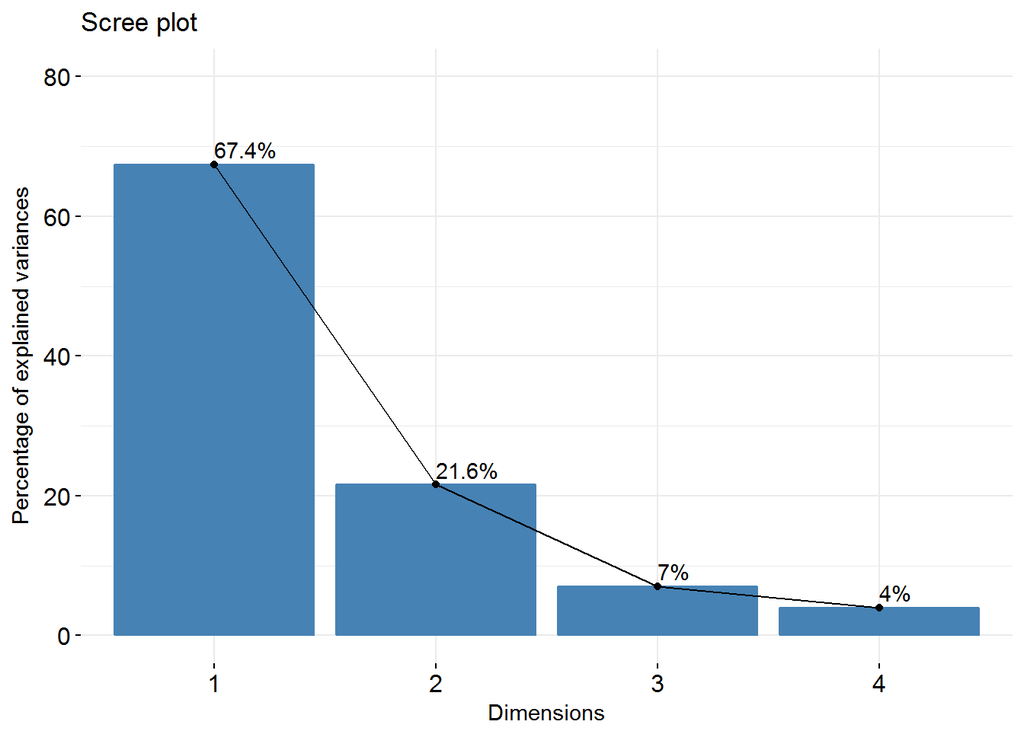

```r
# Visualize eigenvalues/variances
fviz_screeplot(pca4, addlabels=TRUE, ylim=c(0,80))
```

```r
# Extract the results for variables
var <- get_pca_var(pca4)
var
```

```
## Principal Component Analysis Results for variables
##  ===================================================
##   Name       Description
## 1 "$coord"   "Coordinates for the variables"
## 2 "$cor"     "Correlations between variables and dimensions"
## 3 "$cos2"    "Cos2 for the variables"
## 4 "$contrib" "contributions of the variables"
```

```r
# Coordinates of variables
head(var$coord)
```

```
##              Dim.1       Dim.2       Dim.3       Dim.4
## Murder   0.8898789 -0.33564898  0.09452377  0.29414369
## Assault  0.9097623 -0.19722370  0.26455183 -0.25188810
## UrbanPop 0.5213021  0.84234193  0.12192268  0.06196043
## Rape     0.8976058  0.04344787 -0.43265381 -0.07229684
```

```r
# Contribution of variables
head(var$contrib)
```

```
##             Dim.1      Dim.2     Dim.3     Dim.4
## Murder   29.36164 13.0547147  3.179886 54.403763
## Assault  30.68841  4.5072839 24.908695 39.895615
## UrbanPop 10.07621 82.2192587  5.290521  2.414008
## Rape     29.87375  0.2187428 66.620898  3.286613
```

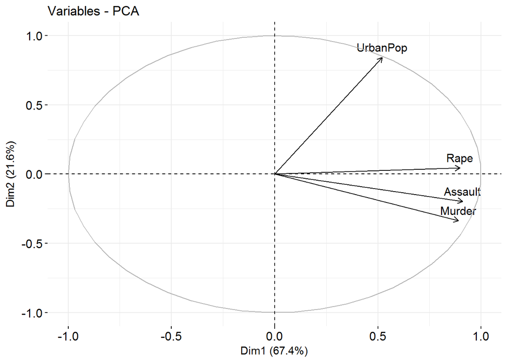

```r
# Graph of variables: default plot
fviz_pca_var(pca4, col.var = "black")
```

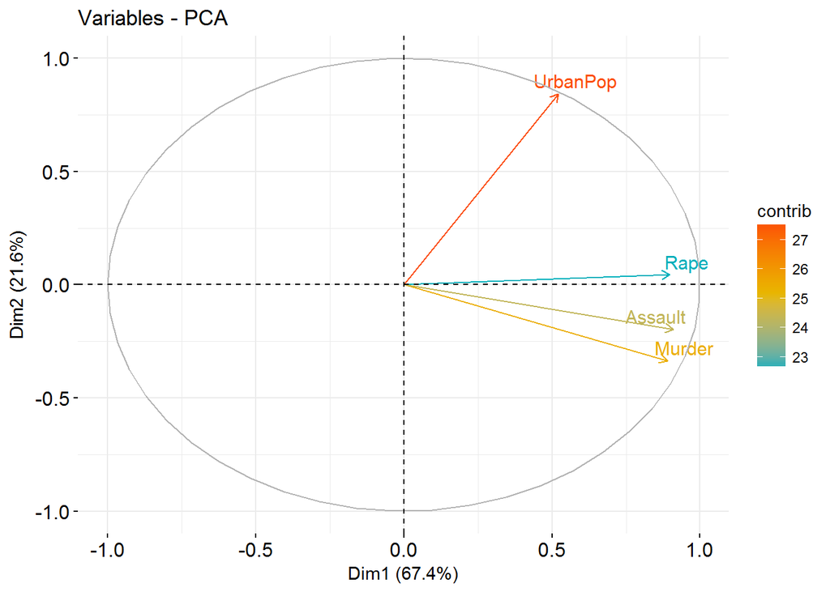

```r
# It’s possible to control variable colors using their contributions (“contrib”) to the principal axes:
fviz_pca_var(pca4, col.var="contrib",
             gradient.cols = c("#00AFBB", "#E7B800", "#FC4E07"),
             repel = TRUE)
```

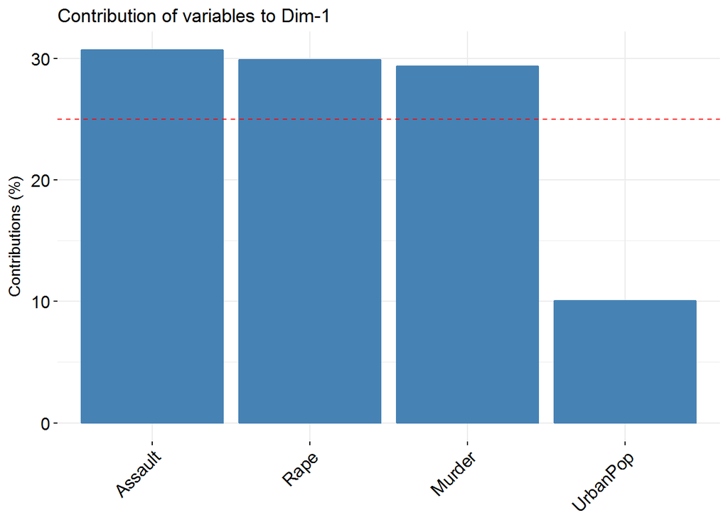

```r
# Contributions of variables to PC1
fviz_contrib(pca4, choice = "var", axes = 1, top = 10)
```

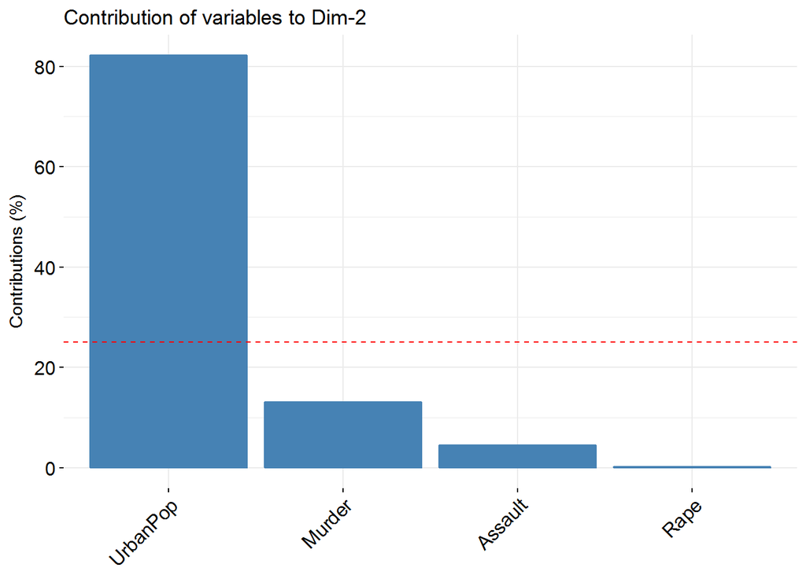

```r
# Contributions of variables to PC2
fviz_contrib(pca4, choice = "var", axes = 2, top = 10)
```

```r
# Extract the results for individuals
ind <- get_pca_ind(pca4)
ind
```

```
## Principal Component Analysis Results for individuals
##  ===================================================
##   Name       Description
## 1 "$coord"   "Coordinates for the individuals"
## 2 "$cos2"    "Cos2 for the individuals"
## 3 "$contrib" "contributions of the individuals"
```

```r
# Coordinates of individuals
head(ind$coord)
```

```
##                Dim.1      Dim.2       Dim.3       Dim.4
## Alabama    1.0217992 -0.9201945  0.33504907  0.16447688
## Alaska     1.5552836 -1.4633512 -1.17846153 -0.68583492
## Arizona    1.7428696  0.5361687  0.02233422 -0.55817118
## Arkansas   0.1804277 -1.2011691  0.04287734 -0.09968703
## California 2.2681927  1.0276677 -0.37174037 -0.39620965
## Colorado   1.5995257  0.6131997 -0.73757366 -0.28168257
```

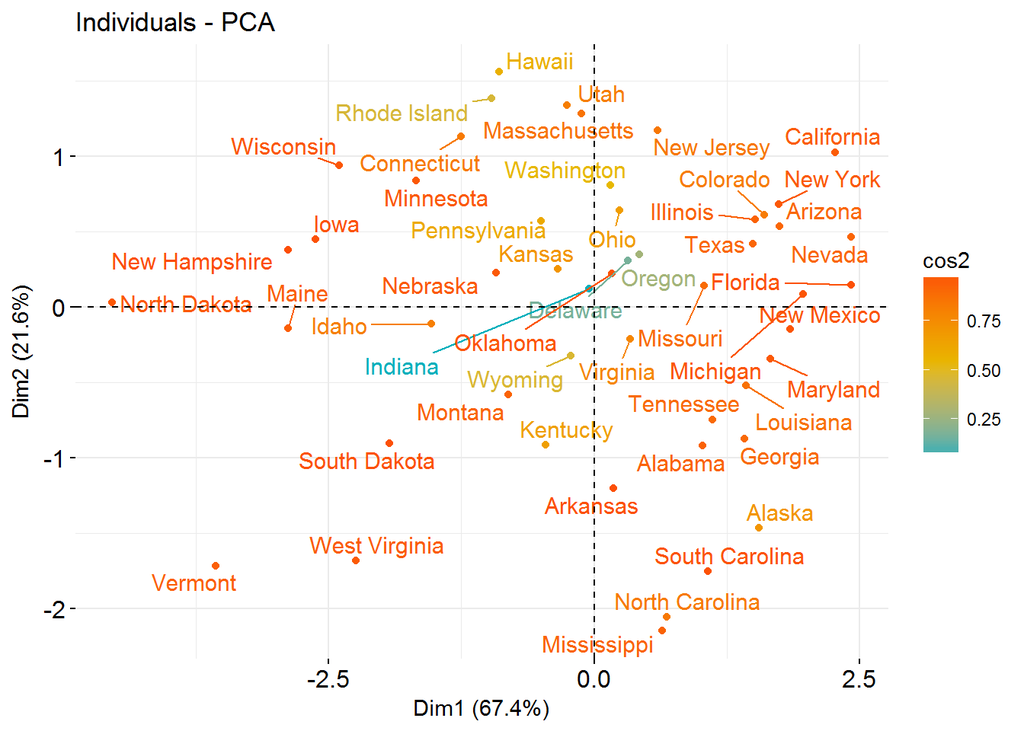

```r
# Graph of individuals
fviz_pca_ind(pca4, col.ind = "cos2",
             gradient.cols = c("#00AFBB", "#E7B800", "#FC4E07"),
             repel = TRUE)
```

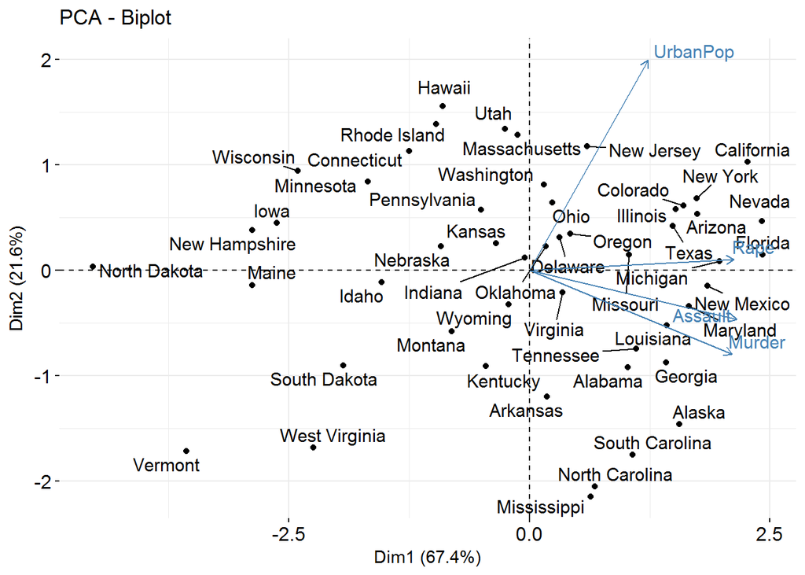

```r
# Biplot of individuals and variables
fviz_pca_biplot(pca4, repel = TRUE)
```

#### Misc PCA on IRIS

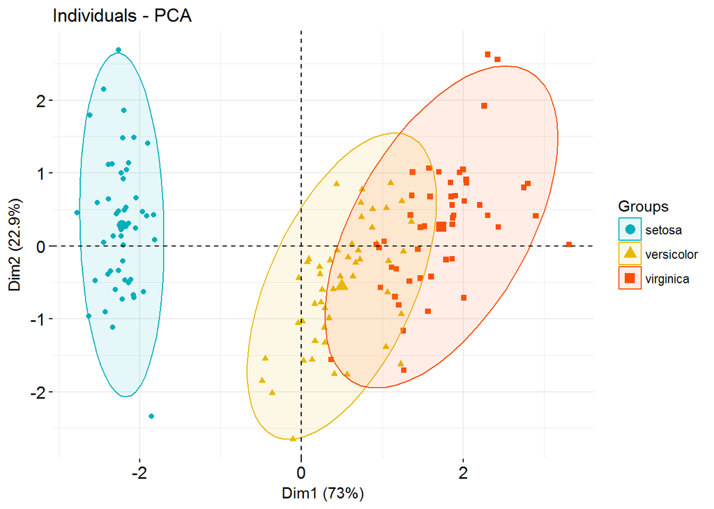

```r
# Compute PCA on the iris data set
# The variable Species (index = 5) is removed
# before PCA analysis
iris.pca <- PCA(iris[,-5], graph = FALSE)
# Visualize
# Use habillage to specify groups for coloring
fviz_pca_ind(iris.pca, label = "none", # hide individual labels
             habillage = iris$Species, # color by groups
             palette = c("#00AFBB", "#E7B800", "#FC4E07"), addEllipses = TRUE)
```

### Example 5 - A Complete Udemy Project - 1

To get started, we need a data set with a lot of columns. We’re going to borrow a data set from NIPS (Neural Information Processing Systems) for a completed 2013 competition. Let’s download our data from the UC Irvine Machine Learning Repository (https://archive.ics.uci.edu/ml/datasets/Gisette) (warning: this is a large ﬁle).

```r
#https://archive.ics.uci.edu/ml/machine-learning-databases/gisette/GISETTE/
gisetteRaw <- read.table("./data/gisette_train.txt", sep = '', header = FALSE, stringsAsFactors = FALSE)

g_labels <- read.table("./data/gisette_train.labels", sep = '', header = FALSE, stringsAsFactors = FALSE)

print(dim(gisetteRaw))
```

```
## [1] 6000 5000
```

```r
gisetteRaw[1:3,]
```

[output not shown]

[output cut: 1601 more lines]

The gisetteRaw data frame has 5000 columns, that’s big and that’s the kind of size we’re looking for. It also has one outcome variable, ‘cluster’. Before we can start the PCA transformation process, we need to remove the extreme near-zero variance as it won’t help us much, risks crashing the script, and slow us down. We load the caret (http://topepo.github.io/caret/index.html) package and call nearZeroVar function with saveMetrics parameter set to true. This will return a data frame with the percentage of zero variance for each feature:

```r
# SMALLER DATA SET: # truncate data set if you're having trouble running prcomp but note the scores won't be the same as in the walkthrough, a few percentage points lower: #
# gisetteRaw <-gisetteRaw[1:2000,]
# g_labels <-data.frame('V1'=g_labels[1:2000,] )

nzv <- nearZeroVar(gisetteRaw, saveMetrics = TRUE)
print(paste('Range:',range(nzv$percentUnique)))
```

```
## [1] "Range: 0.0166666666666667" "Range: 8.6"
```

```r
print(head(nzv))
```

```
##     freqRatio percentUnique zeroVar  nzv
## V1   48.25234     5.2166667   FALSE TRUE
## V2 1180.80000     1.3666667   FALSE TRUE
## V3   41.31579     6.1500000   FALSE TRUE
## V4 5991.00000     0.1666667   FALSE TRUE
## V5  980.00000     1.5333333   FALSE TRUE
## V6  140.00000     3.5166667   FALSE TRUE
```

We remove features with less than 0.1% variance. Note - if working in medicine and the disease rate is very low, we would not remove these low frequency columns

```r
print(paste('Column count before cutoff:',ncol(gisetteRaw)))
```

```
## [1] "Column count before cutoff: 5000"
```

```r
dim(nzv[nzv$percentUnique > 0.1,])
```

```
## [1] 4639    4
```

```r
gisette_nzv <- gisetteRaw[c(rownames(nzv[nzv$percentUnique > 0.1,]))]
print(paste('Column count after cutoff:',ncol(gisette_nzv)))
```

```
## [1] "Column count after cutoff: 4639"
```

#### Without PCA

The data is cleaned up and ready to go. Lets see how well it performs without any PCA transformation. We bind the labels (response/outcome variables) to the set:

```r
gisette_df <- cbind(as.data.frame(sapply(gisette_nzv, as.numeric)), cluster=g_labels$V1)
gisette_df[nrow(gisette_df)-3: nrow(gisette_df),]
```

[output not shown]

[output cut: 8852 more lines]

Going to use GBM (Generalized Boosted Models) (https://cran.rproject.org/web/packages/gbm/index.html). GBM is a classification algo that uses boosted trees. It is also one of the models supported by the caret (http://topepo.github.io/caret/index.html).

To evaluate the data, we split the data set into two parts, one for training and the other for evaluating. If you wanted a more accurate evaluation, I would recommend cross validating the data using multiple splits.

```r
# split data set in 1/2 into training and testing - allows us to compare with and without PCA applied
set.seed(1234)
split <- sample(nrow(gisette_df), floor(0.5*nrow(gisette_df)))
traindf <- gisette_df[split,]
testdf <-  gisette_df[-split,]
```

```r
traindf$cluster <- as.factor(traindf$cluster) #GBM requires label to be a factor so it gets measures as a probability
#and not a root mean square error
fitControl <- trainControl(method="none")
model <- train(cluster~., data=traindf, tuneGrid = expand.grid(n.trees = 50, interaction.depth = 3,
                            shrinkage = 0.1, n.minobsinnode=10), trControl=fitControl, method="gbm", metric='roc')
testdf$cluster <- as.factor(testdf$cluster)
predictions <- predict(object=model, testdf[,setdiff(names(testdf), 'cluster')], type='raw')
```

We use carets **postResample** function to get an accuracy score. A quick note on the predictions. If you do a head on predictions:

```r
head(predictions)
```

```
## [1] 1  1  1  1  -1 -1
## Levels: -1 1
```

You will notice that it returns actual predictions (i.e. actual cluster values) instead of probabilities - to get probabilities, use the ‘type=prob’ instead of ‘type=raw’.

```r
print(postResample(pred=predictions, obs=testdf$cluster))
```

```
##  Accuracy     Kappa
## 0.9516667 0.9032827
```

#### With PCA

Lets reduce the data set using PCA and compare results. As mentioned previously, scaling is important, so we scale the entire data set (not the outcome - cluster) then run the prcomp function. Warning: this step is slow.

```r
# this will take a while - be patient - perhaps 1 hour+
pmatrix <- scale(gisette_nzv)
princ <- prcomp(pmatrix)
```

So, lets extract a data set containing only the ﬁrst principal component analysis (and we will keep adding till we get the performance we seek):

```r
n.comp <- 1  # numner of principal components
dfComponents <- predict(princ, newdata=pmatrix)[,1:n.comp] #predict using the 1st and most influential component

gisette_df <- cbind(as.data.frame(dfComponents), cluster=g_labels$V1)
```

To recap, we have a new data set called gisette_df containing only two columns: dfComponents, and cluster (i.e. PCA component 1 and the outcome variable):

```r
head(gisette_df)
```

```
##   dfComponents cluster
## 1  -0.09733800       1
## 2  -0.06140186      -1
## 3  -0.03489463       1
## 4  -0.03928385       1
## 5   0.04302395       1
## 6   0.03183122       1
```

Lets get the accuracy on this data set:

```r
# split data set into training and testing
set.seed(1234)
split <- sample(nrow(gisette_df), floor(0.5*nrow(gisette_df)))
traindf <- gisette_df[split,]
testdf <-  gisette_df[-split,]

# force the outcome
traindf$cluster <- as.factor(traindf$cluster)
fitControl <- trainControl(method="none")
model <- train(cluster~., data=traindf,
tuneGrid = expand.grid(n.trees = 50, interaction.depth = 3, shrinkage = 0.1, n.minobsinnode=10), trControl=fitControl, method="gbm", metric='roc')
testdf$cluster <- as.factor(testdf$cluster )

# note: here you need to force our single variable data set 'testdf' to a data frame, ot herwise R tries to turn it into a vector
predictions <- predict(object=model, newdata=data.frame('dfComponents'=testdf[,setdiff(names(testdf), 'cluster')]), type='raw')

print(postResample(pred=predictions, obs=testdf$cluster))
```

```
##  Accuracy     Kappa
## 0.7126667 0.4219162
```

```r
n.comp <- 2
dfComponents <- predict(princ, newdata=pmatrix)[,1:n.comp]

gisette_df <- cbind(as.data.frame(dfComponents), cluster=g_labels$V1)

# split data set into training and testing
set.seed(1234)
split <- sample(nrow(gisette_df), floor(0.5*nrow(gisette_df)))
traindf <- gisette_df[split,]
testdf <-  gisette_df[-split,]

# force the outcome
traindf$cluster <- as.factor(traindf$cluster )
fitControl <- trainControl(method="none")
model <- train(cluster~., data=traindf, tuneGrid = expand.grid(n.trees = 50, interaction.depth = 3,
        shrinkage = 0.1, n.minobsinnode=10), trControl=fitControl, method="gbm", metric='roc')
testdf$cluster <- as.factor(testdf$cluster )
predictions <- predict(object=model, newdata=testdf[,setdiff(names(testdf), 'cluster')], type='raw')

print(postResample(pred=predictions, obs=testdf$cluster))
```

```
##  Accuracy     Kappa
## 0.7193333 0.4354248
```

```r
n.comp <- 10
dfComponents <- predict(princ, newdata=pmatrix)[,1:n.comp]

gisette_df <- cbind(as.data.frame(dfComponents), cluster=g_labels$V1)

# split data set into training and testing
set.seed(1234)
split <- sample(nrow(gisette_df), floor(0.5*nrow(gisette_df)))
traindf <- gisette_df[split,]
testdf <-  gisette_df[-split,]

# force the outcome
traindf$cluster <- as.factor(traindf$cluster )
fitControl <- trainControl(method="none")
model <- train(cluster~., data=traindf, tuneGrid = expand.grid(n.trees = 50, interaction.depth = 3,
        shrinkage = 0.1, n.minobsinnode=10), trControl=fitControl, method="gbm", metric='roc')
testdf$cluster <- as.factor(testdf$cluster )
predictions <- predict(object=model, newdata=testdf[,setdiff(names(testdf), 'cluster')], type='raw')

print(postResample(pred=predictions, obs=testdf$cluster))
```

```
##  Accuracy     Kappa
## 0.9300000 0.8599243
```

```r
n.comp <- 20
dfComponents <- predict(princ, newdata=pmatrix)[,1:n.comp]

gisette_df <- cbind(as.data.frame(dfComponents), cluster=g_labels$V1)

# split data set into training and testing
set.seed(1234)
split <- sample(nrow(gisette_df), floor(0.5*nrow(gisette_df)))
traindf <- gisette_df[split,]
testdf <-  gisette_df[-split,]

# force the outcome
traindf$cluster <- as.factor(traindf$cluster)
fitControl <- trainControl(method="none")
model <- train(cluster~., data=traindf, tuneGrid = expand.grid(n.trees = 50, interaction.depth = 3,
        shrinkage = 0.1, n.minobsinnode=10), trControl=fitControl, method="gbm", metric='roc')
testdf$cluster <- as.factor(testdf$cluster )
predictions <- predict(object=model, newdata=testdf[,setdiff(names(testdf), 'cluster')], type='raw')

print(postResample(pred=predictions, obs=testdf$cluster))
```

```
##  Accuracy     Kappa
## 0.9303333 0.8605418
```

A few notes:

- PCA data is not very useful. The values transformed by PCA cannot be interpretted (outside of the biplot)
  - If you need to explain interactions and coefficients, consider other methods like **varible selection**

### Example 6 - A Complete Project - 2

Copied from https://www.analyticsvidhya.com/blog/2016/03/practical-guide-principal-component-analysis-python/

PCA can be applied only on numerical data. Therefore, if the data has categorical variables they must be converted to numerical. Also, make sure you have done the basic data cleaning prior to implementing this technique. Let’s quickly finish with initial data loading and cleaning steps:

```r
#load train and test file
train <- read.csv("./data/train_BigMart.csv")
test <- read.csv("./data/test_BigMart.csv")
#add a column
test$Item_Outlet_Sales <- 1
#combine the data set
combi <- rbind(train, test)
#impute missing values with median
combi$Item_Weight[is.na(combi$Item_Weight)] <- median(combi$Item_Weight, na.rm = TRUE)
#impute 0 with median
combi$Item_Visibility <- ifelse(combi$Item_Visibility == 0, median(combi$Item_Visibility), combi$Item_Visibility)
#find mode and impute
table(combi$Outlet_Size, combi$Outlet_Type)
```

```
##
##          Grocery Store Supermarket Type1 Supermarket Type2
##                    925              3091                 0
##   High               0              1553                 0
##   Medium             0              1550              1546
##   Small            880              3100                 0
##
##          Supermarket Type3
##                          0
##   High                   0
##   Medium              1559
##   Small                  0
```

```r
levels(combi$Outlet_Size)[1] <- "Other"
```

Till here, we have imputed missing values. Now we are left with removing the dependent (response) variable and other identifier variables (if any). As we said above, we are practicing an unsupervised learning technique, hence response variable must be removed.

```r
#remove the dependent and identifier variables
my_data <- subset(combi, select = -c(Item_Outlet_Sales, Item_Identifier,  Outlet_Identifier))
```

Let’s check the available variables ( a.k.a predictors) in the data set.

```r
#check available variables
colnames(my_data)
```

```
## [1] "Item_Weight"               "Item_Fat_Content"
## [3] "Item_Visibility"           "Item_Type"
## [5] "Item_MRP"                  "Outlet_Establishment_Year"
## [7] "Outlet_Size"               "Outlet_Location_Type"
## [9] "Outlet_Type"
```

Since PCA works on numeric variables, let’s see if we have any variable other than numeric.

```r
#check variable class
str(my_data)
```

```
## 'data.frame':    14204 obs. of  9 variables:
##  $ Item_Weight              : num  9.3 5.92 17.5 19.2 8.93 ...
##  $ Item_Fat_Content         : Factor w/ 5 levels "LF","low fat",..: 3 5 3 5 3 5 5 3 5 5 ...
##  $ Item_Visibility          : num  0.016 0.0193 0.0168 0.054 0.054 ...
##  $ Item_Type                : Factor w/ 16 levels "Baking Goods",..: 5 15 11 7 10 1 14 14 6 6 ...
##  $ Item_MRP                 : num  249.8 48.3 141.6 182.1 53.9 ...
##  $ Outlet_Establishment_Year: int  1999 2009 1999 1998 1987 2009 1987 1985 2002 2007 ...
##  $ Outlet_Size              : Factor w/ 4 levels "Other","High",..: 3 3 3 1 2 3 2 3 1 1 ...
##  $ Outlet_Location_Type     : Factor w/ 3 levels "Tier 1","Tier 2",..: 1 3 1 3 3 3 3 3 2 2 ...
##  $ Outlet_Type              : Factor w/ 4 levels "Grocery Store",..: 2 3 2 1 2 3 2 4 2 2 ...
```

Sadly, 6 out of 9 variables are categorical in nature. We have some additional work to do now. We’ll convert these categorical variables into numeric using one hot encoding.

```r
#load library
library(dummies)
#create a dummy data frame
new_my_data <- dummy.data.frame(my_data, names = c("Item_Fat_Content","Item_Type", "Outlet_Establishment_Year","Outlet_Size",
"Outlet_Location_Type","Outlet_Type"))
```

To check, if we now have a data set of integer values, simple write:

```r
str(new_my_data)
```

```
## 'data.frame':    14204 obs. of  44 variables:
##  $ Item_Weight                   : num  9.3 5.92 17.5 19.2 8.93 ...
##  $ Item_Fat_ContentLF            : int  0 0 0 0 0 0 0 0 0 0 ...
##  $ Item_Fat_Contentlow fat       : int  0 0 0 0 0 0 0 0 0 0 ...
##  $ Item_Fat_ContentLow Fat       : int  1 0 1 0 1 0 0 1 0 0 ...
##  $ Item_Fat_Contentreg           : int  0 0 0 0 0 0 0 0 0 0 ...
##  $ Item_Fat_ContentRegular       : int  0 1 0 1 0 1 1 0 1 1 ...
##  $ Item_Visibility               : num  0.016 0.0193 0.0168 0.054 0.054 ...
##  $ Item_TypeBaking Goods         : int  0 0 0 0 0 1 0 0 0 0 ...
##  $ Item_TypeBreads               : int  0 0 0 0 0 0 0 0 0 0 ...
##  $ Item_TypeBreakfast            : int  0 0 0 0 0 0 0 0 0 0 ...
##  $ Item_TypeCanned               : int  0 0 0 0 0 0 0 0 0 0 ...
##  $ Item_TypeDairy                : int  1 0 0 0 0 0 0 0 0 0 ...
##  $ Item_TypeFrozen Foods         : int  0 0 0 0 0 0 0 0 1 1 ...
##  $ Item_TypeFruits and Vegetables: int  0 0 0 1 0 0 0 0 0 0 ...
```

[output cut: 37 more lines]

And, we now have all the numerical values. Let’s divide the data into test and train.

```r
#divide the new data
pca.train <- new_my_data[1:nrow(train),]
pca.test <- new_my_data[-(1:nrow(train)),]
```

We can now go ahead with PCA.

The base R function prcomp() is used to perform PCA. By default, it centers the variable to have mean equals to zero. With parameter scale. = T, we normalize the variables to have standard deviation equals to 1.

```r
#principal component analysis
prin_comp <- prcomp(pca.train, scale. = T)
names(prin_comp)
```

```
## [1] "sdev"     "rotation" "center"   "scale"    "x"
```

The prcomp() function results in 5 useful measures:

1. center and scale refers to respective mean and standard deviation of the variables that are used for normalization prior to implementing PCA

```r
#outputs the mean of variables
prin_comp$center
```

```
##                    Item_Weight             Item_Fat_ContentLF
##                   1.281342e+01                   3.707615e-02
##        Item_Fat_Contentlow fat        Item_Fat_ContentLow Fat
##                   1.314091e-02                   5.970902e-01
##            Item_Fat_Contentreg        Item_Fat_ContentRegular
##                   1.372756e-02                   3.389652e-01
##                Item_Visibility          Item_TypeBaking Goods
##                   6.946593e-02                   7.602957e-02
##                Item_TypeBreads             Item_TypeBreakfast
##                   2.944972e-02                   1.290625e-02
##                Item_TypeCanned                 Item_TypeDairy
##                   7.614690e-02                   8.001877e-02
##          Item_TypeFrozen Foods Item_TypeFruits and Vegetables
##                   1.004341e-01                   1.445500e-01
##           Item_TypeHard Drinks    Item_TypeHealth and Hygiene
##                   2.510853e-02                   6.101138e-02
##             Item_TypeHousehold                  Item_TypeMeat
##                   1.067699e-01                   4.986507e-02
##                Item_TypeOthers               Item_TypeSeafood
##                   1.982870e-02                   7.509093e-03
##           Item_TypeSnack Foods           Item_TypeSoft Drinks
##                   1.407955e-01                   5.221166e-02
##         Item_TypeStarchy Foods                       Item_MRP
##                   1.736478e-02                   1.409928e+02
##  Outlet_Establishment_Year1985  Outlet_Establishment_Year1987
##                   1.716532e-01                   1.093512e-01
##  Outlet_Establishment_Year1997  Outlet_Establishment_Year1998
##                   1.091165e-01                   6.511792e-02
##  Outlet_Establishment_Year1999  Outlet_Establishment_Year2002
##                   1.091165e-01                   1.089992e-01
##  Outlet_Establishment_Year2004  Outlet_Establishment_Year2007
##                   1.091165e-01                   1.086472e-01
##  Outlet_Establishment_Year2009               Outlet_SizeOther
##                   1.088818e-01                   2.827643e-01
##                Outlet_SizeHigh              Outlet_SizeMedium
##                   1.093512e-01                   3.277015e-01
##               Outlet_SizeSmall     Outlet_Location_TypeTier 1
##                   2.801830e-01                   2.801830e-01
##     Outlet_Location_TypeTier 2     Outlet_Location_TypeTier 3
##                   3.267629e-01                   3.930541e-01
##       Outlet_TypeGrocery Store   Outlet_TypeSupermarket Type1
##                   1.270679e-01                   6.543471e-01
##   Outlet_TypeSupermarket Type2   Outlet_TypeSupermarket Type3
##                   1.088818e-01                   1.097032e-01
```

```r
#outputs the standard deviation of variables
prin_comp$scale
```

```
##                    Item_Weight             Item_Fat_ContentLF
##                     4.22724041                     0.18895951
##        Item_Fat_Contentlow fat        Item_Fat_ContentLow Fat
##                     0.11388481                     0.49051169
##            Item_Fat_Contentreg        Item_Fat_ContentRegular
##                     0.11636453                     0.47338575
##                Item_Visibility          Item_TypeBaking Goods
##                     0.04889103                     0.26506097
##                Item_TypeBreads             Item_TypeBreakfast
##                     0.16907333                     0.11287682
##                Item_TypeCanned                 Item_TypeDairy
##                     0.26524857                     0.27133818
##          Item_TypeFrozen Foods Item_TypeFruits and Vegetables
##                     0.30059559                     0.35166722
##           Item_TypeHard Drinks    Item_TypeHealth and Hygiene
##                     0.15646394                     0.23936523
##             Item_TypeHousehold                  Item_TypeMeat
##                     0.30883862                     0.21767890
##                Item_TypeOthers               Item_TypeSeafood
##                     0.13941952                     0.08633412
##           Item_TypeSnack Foods           Item_TypeSoft Drinks
##                     0.34783088                     0.22246665
##         Item_TypeStarchy Foods                       Item_MRP
##                     0.13063401                    62.27506651
##  Outlet_Establishment_Year1985  Outlet_Establishment_Year1987
##                     0.37710084                     0.31209761
##  Outlet_Establishment_Year1997  Outlet_Establishment_Year1998
##                     0.31180363                     0.24674829
##  Outlet_Establishment_Year1999  Outlet_Establishment_Year2002
##                     0.31180363                     0.31165647
##  Outlet_Establishment_Year2004  Outlet_Establishment_Year2007
##                     0.31180363                     0.31121430
##  Outlet_Establishment_Year2009               Outlet_SizeOther
##                     0.31150919                     0.45036923
##                Outlet_SizeHigh              Outlet_SizeMedium
##                     0.31209761                     0.46940290
##               Outlet_SizeSmall     Outlet_Location_TypeTier 1
##                     0.44911487                     0.44911487
##     Outlet_Location_TypeTier 2     Outlet_Location_TypeTier 3
##                     0.46905726                     0.48845733
##       Outlet_TypeGrocery Store   Outlet_TypeSupermarket Type1
##                     0.33306860                     0.47560858
##   Outlet_TypeSupermarket Type2   Outlet_TypeSupermarket Type3
##                     0.31150919                     0.31253773
```

2. The rotation measure provides the principal component loading. Each column of rotation matrix contains the principal component loading vector. This is the most important measure we should be interested in.

```r
prin_comp$rotation[1:2]
```

```
## [1] -0.001044124  0.009172576
```

```r
prin_comp$rotation[1:5,1:4]
```

```
##                                  PC1           PC2          PC3
## Item_Weight             -0.001044124 -0.0004384151  0.021454235
## Item_Fat_ContentLF       0.009172576  0.0019042858 -0.008383420
## Item_Fat_Contentlow fat  0.003428769 -0.0055492764  0.003302283
## Item_Fat_ContentLow Fat -0.007836003 -0.0065124968  0.021090747
## Item_Fat_Contentreg      0.001251767 -0.0033104683  0.006895653
##                                   PC4
## Item_Weight             -0.0009241751
## Item_Fat_ContentLF      -0.0067791081
## Item_Fat_Contentlow fat -0.0200639450
## Item_Fat_ContentLow Fat  0.0263226605
## Item_Fat_Contentreg      0.0128246294
```

3. In order to compute the principal component score vector, we don’t need to multiply the loading with data. Rather, the matrix x has the principal component score vectors in a 8523 × 44 dimension.

```r
dim(prin_comp$x)
```

```
## [1] 8523   44
```

Let’s plot the resultant principal components.

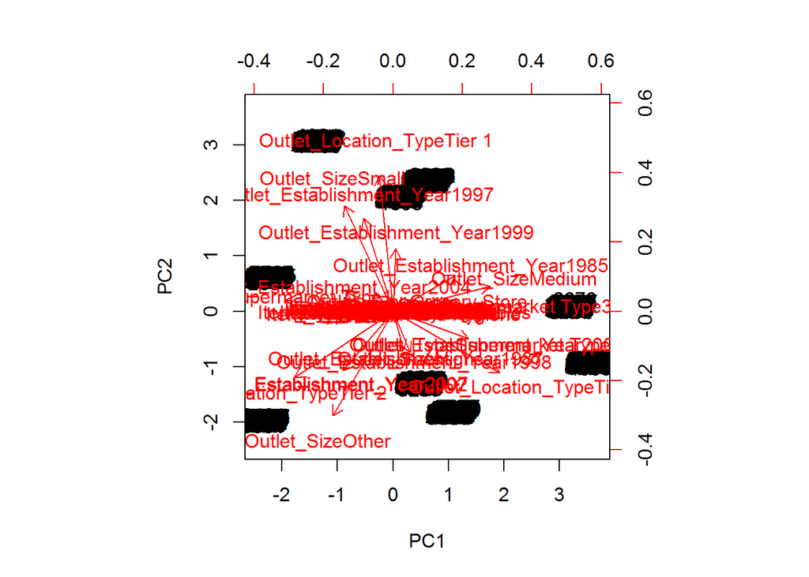

```r
biplot(prin_comp, scale = 0)
```

The parameter scale = 0 ensures that arrows are scaled to represent the loadings. To make inference from image above, focus on the extreme ends (top, bottom, left, right) of this graph.

We infer than first principal component corresponds to a measure of Outlet_TypeSupermarket, Outlet_Establishment_Year 2007. Similarly, it can be said that the second component corresponds to a measure of Outlet_Location_TypeTier1, Outlet_Sizeother. For exact measure of a variable in a component, you should look at rotation matrix(above) again.

4. The prcomp() function also provides the facility to compute standard deviation of each principal component. sdev refers to the standard deviation of principal components.

```r
#compute standard deviation of each principal component
std_dev <- prin_comp$sdev
#compute variance
pr_var <- std_dev^2
#check variance of first 10 components
pr_var[1:10]
```

```
##  [1] 4.564631 3.219279 2.744497 2.535883 2.190449 2.021640 1.935010
##  [8] 1.266311 1.205757 1.169495
```

We aim to find the components which explain the maximum variance. This is because, we want to retain as much information as possible using these components. So, higher is the explained variance, higher will be the information contained in those components.

To compute the proportion of variance explained by each component, we simply divide the variance by sum of total variance. This results in:

```r
#proportion of variance explained
prop_varex <- pr_var/sum(pr_var)
prop_varex[1:20]
```

```
##  [1] 0.10374160 0.07316543 0.06237493 0.05763369 0.04978294 0.04594636
##  [7] 0.04397749 0.02877979 0.02740357 0.02657943 0.02631063 0.02577906
## [13] 0.02549683 0.02511309 0.02477200 0.02469167 0.02460995 0.02446028
## [19] 0.02398721 0.02373467
```

This shows that first principal component explains 10.3% variance. Second component explains 7.3% variance. Third component explains 6.2% variance and so on. So, how do we decide how many components should we select for modeling stage ?

The answer to this question is provided by a scree plot. A scree plot is used to access components or factors which explains the most of variability in the data. It represents values in descending order.

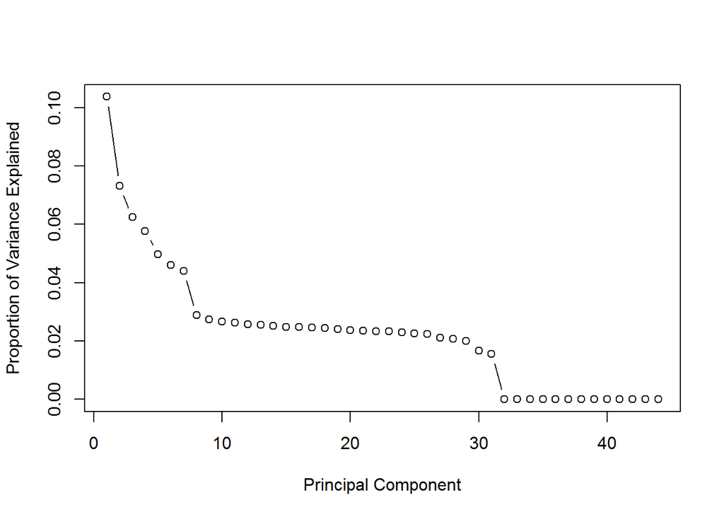

```r
#scree plot
plot(prop_varex, xlab = "Principal Component",
ylab = "Proportion of Variance Explained", type = "b")
```

The plot above shows that ~ 30 components explains around 98.4% variance in the data set. In order words, using PCA we have reduced 44 predictors to 30 without compromising on explained variance. This is the power of PCA> Let’s do a confirmation check, by plotting a cumulative variance plot. This will give us a clear picture of number of components.

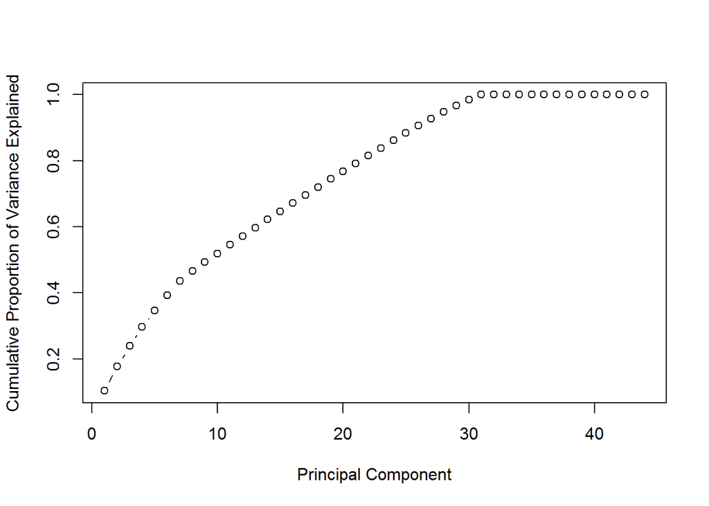

```r
#cumulative scree plot
plot(cumsum(prop_varex), xlab = "Principal Component",
ylab = "Cumulative Proportion of Variance Explained", type = "b")
```

This plot shows that 30 components results in variance close to ~ 98%. Therefore, in this case, we’ll select number of components as 30 [PC1 to PC30] and proceed to the modeling stage. This completes the steps to implement PCA on train data. For modeling, we’ll use these 30 components as predictor variables and follow the normal procedures.

#### Predictive Modeling with PCA Components

After we have calculated the principal components on training set, lets now understand the process of predicting on test data using these components. The process is simple. Just like we obtained PCA components on training set, we’ll get another bunch of components on testing set. Finally, we train the model.

But, few important points to understand:

- We should not combine the train and test set to obtain PCA components of whole data at once. Because, this would violate the entire assumption of generalization since test data would get ‘leaked’ into the training set. In other words, the test data set would no longer remain ‘unseen’. Eventually, this will hammer down the generalization capability of the model.
- We should not perform PCA on test and train data sets separately. Because, the resultant vectors from train and test PCAs will have different directions ( due to unequal variance). Due to this, we’ll end up comparing data registered on different axes. Therefore, the resulting vectors from train and test data should have same axes.

So, what should we do?

We should do exactly the same transformation to the test set as we did to training set, including the center and scaling feature.

```r
#add a training set with principal components
train.data <- data.frame(Item_Outlet_Sales = train$Item_Outlet_Sales, prin_comp$x)
#we are interested in first 30 PCAs
train.data <- train.data[,1:31]
#run a decision tree
rpart.model <- rpart(Item_Outlet_Sales ~ .,data = train.data, method = "anova")
rpart.model
```

```
## n= 8523
##
## node), split, n, deviance, yval
##       * denotes terminal node
##
##  1) root 8523 24817270000 2181.2890
##    2) PC3< -1.671844 1083    73623120  339.8285 *
##    3) PC3>=-1.671844 7440 20536640000 2449.3400
##      6) PC27< 0.02464682 3838  5499852000 1780.8280
##       12) PC27< -1.079021 1017   586793000 1132.8500 *
##       13) PC27>=-1.079021 2821  4332103000 2014.4310
##         26) PC9< 0.3193864 1627  1972546000 1675.5750
##           52) PC19>=-1.337507 1439  1294309000 1534.0690 *
##           53) PC19< -1.337507 188   428870300 2758.6960 *
##         27) PC9>=0.3193864 1194  1918174000 2476.1710 *
##      7) PC27>=0.02464682 3602 11493930000 3161.6530
##       14) PC6< 2.648969 3155  8039466000 2925.5700
##         28) PC9< -0.1215489 1412  2827138000 2417.5500
##           56) PC27< 1.461566 1182  1950290000 2217.1510 *
##           57) PC27>=1.461566 230   585430300 3447.4280 *
##         29) PC9>=-0.1215489 1743  4552703000 3337.1150 *
##       15) PC6>=2.648969 447  2037483000 4827.9660
##         30) PC8>=0.7209545 118   302595100 3358.4530 *
##         31) PC8< 0.7209545 329  1388678000 5355.0250 *
```

```r
#transform test into PCA
test.data <- predict(prin_comp, newdata = pca.test)
test.data <- as.data.frame(test.data)
#select the first 30 components
test.data <- test.data[,1:30]
#make prediction on test data
rpart.prediction <- predict(rpart.model, test.data)
```

### Points to Remember

- PCA is used to overcome features redundancy in a data set.
- These features are low dimensional in nature.
- These features a.k.a components are a resultant of normalized linear combination of original predictor variables.
- These components aim to capture as much information as possible with high explained variance.
- The first component has the highest variance followed by second, third and so on.
- The components must be uncorrelated (remember orthogonal direction? ). See above.
- Normalizing data becomes extremely important when the predictors are measured in different units.
- PCA works best on data set having 3 or higher dimensions. Because, with higher dimensions, it becomes increasingly difficult to make interpretations from the resultant cloud of data.
- PCA is applied on a data set with numeric variables.
- PCA is a tool which helps to produce better visualizations of high dimensional data.